# QC Analysis of ICB_IMmotion150

Nasim Bondar Sahebi

2024-04-11

## load libraries

```r
library(ggplot2)
library(dplyr)
library(MultiAssayExperiment)
library(pheatmap)
library(DT)
library(tibble)
library(MultiAssayExperiment)
library(edgeR)
library(limma)
library(RColorBrewer)
library(ComplexHeatmap)
library(circlize)
```

## Data Loading and Preparation

**Data Overview**:

- **Study Reference**: [PubMed ID PMC6721896](https://pubmed.ncbi.nlm.nih.gov/29867230/)
- **Patient Count** : 326 ( 325 samples have Rna-se ad 326 samples have WES)
- ** Multi-omices type**: Rna-seq and WES
- **Treatment Details** :
- **PD-1/PD-L1**: 110 patients
- **IO+targeted**: 108 patients
- **targeted**: 108 patients

Load multiassay .rds file, extract clinical, expression and annotations data; prepare gene expression data for analysis.

```r
# Load your multiassay result and extract clinical data, expression data, and annotation

# Load mae obj
mae <- readRDS("~/BHK lab/ICB/ICB_IMmotion150/output data/ICB_IMmotion150.rds")

# Extract Clinical data
clin <- data.frame(colData(mae))

# Mae has five assays: "expr_gene_tpm", "expr_gene_counts", "expr_isoform_tpm", "expr_isoform_counts" and "snv"

# Extract the 'expr_gene_tpm': TPM expression values for genes, normalized for length and sequencing depth.
expr <- assays(mae)[["expr_gene_tpm"]]  # dimension 61544 x 325
snv <- assays(mae)[["snv"]] # dimension 33039 x 326

# Extracting the annotation
annot_expr <- data.frame(rowData(mae@ExperimentList$expr_gene_tpm))
annot_snv <- data.frame(rowData(mae@ExperimentList$snv))

# Display first few rows of the dataset
DT::datatable(expr[1:8, 1:4])
```

|  | EGAN00001749346 | EGAN00001749347 | EGAN00001749348 | EGAN00001749349 |
| --- | --- | --- | --- | --- |
| ENSG00000000003.15 | 4.22679616973224 | 4.14496393875857 | 4.28922519555747 | 3.9357097959754 |
| ENSG00000000005.6 | 5.28582256721189 | 4.95830873325184 | 5.45706318574213 | 5.02742584422309 |
| ENSG00000000419.14 | 4.96205936064619 | 5.11510588500985 | 4.95239841828796 | 4.95662615117346 |
| ENSG00000000457.14 | 4.82032583872493 | 4.57986800354541 | 4.9849628789208 | 4.57074976963901 |
| ENSG00000000460.17 | 5.26419083792401 | 5.30524786242107 | 5.39308420977529 | 5.00137847704639 |
| ENSG00000000938.13 | 4.47600036822157 | 4.86417984069584 | 4.60774479171877 | 3.46706783897672 |
| ENSG00000000971.17 | 5.34589698047111 | 4.90259658285529 | 5.17416071902573 | 4.86266568990224 |
| ENSG00000001036.14 | 4.65159508261478 | 4.82067128254211 | 4.91158565386104 | 4.97903320716862 |

```r
DT::datatable(snv[1:8, 1:4])
```

|  | EGAN00001749346 | EGAN00001749347 | EGAN00001749348 | EGAN00001749349 |
| --- | --- | --- | --- | --- |
| A1BG | C&gt;A;T&gt;C | T&gt;C | C&gt;T;T&gt;C | G&gt;A;T&gt;C |
| A1BG-AS1 | A&gt;G |  |  |  |
| A1CF | T&gt;G |  |  |  |
| A2M | GA&gt;G;T&gt;C;G&gt;T;C&gt;T;T&gt;C | GA&gt;G,GAA;AG&gt;A;T&gt;C;T&gt;C;T&gt;G | GA&gt;G,AA,GAA;T&gt;C;A&gt;T;T&gt;C | GA&gt;G,AA,GAA;T&gt;C;T&gt;C |
| A2M-AS1 |  |  |  |  |
| A2ML1 | G&gt;T;C&gt;A;C&gt;T;TC&gt;T;A&gt;G;A&gt;G | C&gt;A;C&gt;A,T;A&gt;G;A&gt;G | C&gt;A;G&gt;A;C&gt;T;A&gt;G;A&gt;G | C&gt;A;A&gt;G;G&gt;A;A&gt;G |
| A2ML1-AS2 |  |  |  |  |
| A2MP1 | G&gt;T |  |  | C&gt;A |

### Expression Preparation

This step involves subsetting our expression dataframe to include only protein-coding genes and the Genes of Interest, as defined in the paper [PubMed ID PMC6721896](https://pubmed.ncbi.nlm.nih.gov/29867230/). We set the gene names as row names for clarity. The gene signatures are specified as follows: - **Angio23**: `VEGFA`, `KDR`, `ESM1`, `PECAM1`, `ANGPTL4`, `CD34` - **Teff24**: `CD8A`, `EOMES`, `PRF1`, `IFNG`, `CD274` - **Myeloid Inflammation29–33**: `IL-6`, `CXCL1`, `CXCL2`, `CXCL3`, `CXCL8`, `PTGS2`

This prepares our dataset for the subsequent gene expression analysis.

```r
## 1. First:for our expression dat awith log(TPM + 0.001)

# Step 1: Filter to include only protein-coding genes
annot_proteincoding <- annot_expr[annot_expr$gene_type == "protein_coding",]

# Define genes of interests
genes_of_interest <- c(
  "VEGFA", "KDR", "ESM1", "PECAM1", "ANGPTL4", "CD34",  # Angio23 genes
  "CD8A", "EOMES", "PRF1", "IFNG", "CD274",             # Teff24 genes
  "IL6", "CXCL1", "CXCL2", "CXCL3", "CXCL8", "PTGS2"    # Myeloid inflammation genes
)

# Step 2: Subset the protein-coding dataframe to include only the genes of interest
annot_proteincoding_subset <- annot_proteincoding[annot_proteincoding$gene_name %in% genes_of_interest,] #19988 protein coding genes

# Step 3: Filter the expr dataframe to include only rows corresponding to the genes of interest
expr <- expr[rownames(expr) %in% rownames(annot_proteincoding_subset),] # dimension 17 x 325

#set gene_id column for merging purpose
expr$gene_id <- rownames(expr)

# Step 4: Merge to add gene names and remove gene_id column
expr <- merge(expr, annot_proteincoding_subset[, c("gene_name", "gene_id")], by = "gene_id", all.x = TRUE)
expr$gene_id <- NULL

# Step 5: Set gene names as row names for the expr dataframe
rownames(expr) <- expr$gene_name
expr$gene_name <- NULL

# Display expr
DT::datatable(expr)
```

|  | EGAN00001749346 | EGAN00001749347 | EGAN00001749348 | EGAN00001749349 | EGAN00001749350 | EGAN00001749351 | EGAN00001749352 | EGAN00001749353 | EGAN00001749354 | EGAN00001749355 | EGAN00001749356 | EGAN00001749357 | EGAN00001749358 | EGAN00001749359 | EGAN00001749360 | EGAN00001749361 | EGAN00001749362 | EGAN00001749363 | EGAN00001749364 | EGAN00001749365 | EGAN00001749366 | EGAN00001749367 | EGAN00001749368 | EGAN00001749369 | EGAN00001749370 | EGAN00001749371 | EGAN00001749372 | EGAN00001749373 | EGAN00001749374 | … |
| --- | --- | --- | --- | --- | --- | --- | --- | --- | --- | --- | --- | --- | --- | --- | --- | --- | --- | --- | --- | --- | --- | --- | --- | --- | --- | --- | --- | --- | --- | --- |
| PTGS2 | 4.46407998507914 | 4.40318085203881 | 4.65428340771866 | 4.31221641693176 | 4.45158801993105 | 4.20214515716224 | 4.86166854632791 | 4.08942078538434 | 4.93605688116387 | 4.82360750749568 | 4.69500214387984 | 4.72083191478006 | 4.57600345323052 | 5.73743370721811 | 4.30687978331356 | 4.57218615280818 | 4.46322908125179 | 4.26081636219426 | 5.20802407249733 | 3.95931413320904 | 4.76766110053327 | 5.12776457371911 | 4.52861990738581 | 4.43308576475394 | 4.53784019319823 | 4.48593670804564 | 4.43583570427339 | 4.74477580406145 | 4.71526929412096 | … |
| CXCL2 | 4.4540758991474 | 4.78244941504452 | 5.265041350755 | 5.52989863512593 | 5.28936059079865 | 4.75013569765432 | 4.39859395434449 | 5.04847474843094 | 4.39129828236139 | 3.99245700088856 | 4.67550155945035 | 3.99674033388266 | 5.27227630920745 | 2.45611402172011 | 4.32445664755574 | 3.94498537460889 | 4.55056703326063 | 4.78188865467325 | 3.98515377216555 | 5.23331174290594 | 4.18403777825793 | 3.16316158041681 | 4.59959960456313 | 4.20446584337036 | 4.29583533956834 | 4.82538498036572 | 3.96167989560668 | 3.59993064190544 | 5.38907618803449 | … |
| IFNG | 4.16902039159923 | 3.89498291094214 | 4.07722469774945 | 3.91798458865063 | 3.81128931651732 | 3.83376130475737 | 4.34057395055746 | 3.60112747785666 | 4.32583406495197 | 4.4881802711741 | 4.12976774070106 | 4.12583822984793 | 3.88024960740736 | 5.08825331335507 | 4.16549150919117 | 3.89778877146113 | 4.18679082510885 | 3.67831450217192 | 4.36194515793768 | 3.33624279412208 | 3.9442501758468 | 4.79648366909493 | 4.20769361440714 | 3.89860602461701 | 4.05901874170002 | 3.92993974292623 | 3.96742593833815 | 4.36016136695386 | 3.9383552439695 | … |
| VEGFA | 4.21714654666176 | 4.86565881546928 | 4.19961142152681 | 5.07810493915263 | 5.13291710106554 | 4.50324319597085 | 3.22940455246562 | 4.87324420433524 | 4.3782776787025 | 3.64867381997932 | 3.56280963091549 | 4.12955255774334 | 4.79120171295592 | 1.71785180879999 | 4.49516928506828 | 3.37768972120191 | 3.52346408808446 | 4.18286720393911 | 3.67120270535699 | 4.87190873777966 | 4.53756016649974 | 2.75773550925152 | 4.5433573415403 | 3.83597523698322 | 4.21881259477779 | 4.68210887547552 | 3.54583476013064 | 3.84982820087267 | 4.1817542237056 | … |
| CD274 | 5.26054570231947 | 5.24657784853006 | 5.57259951986439 | 5.12100295274621 | 5.2062249323203 | 4.41665682156343 | 5.19765653436072 | 4.80841733778064 | 5.02416254892152 | 5.38195887055693 | 5.59774012354211 | 5.65737824336987 | 4.96214412632617 | 6.06196893054057 | 5.58697640714448 | 5.39235346071398 | 4.8729214106672 | 4.91660625298043 | 5.47067379379421 | 4.55520580013994 | 5.69779990810174 | 5.59244907860657 | 5.18294878920016 | 4.87214086488598 | 5.43179477571146 | 5.24392674952585 | 4.88984647945172 | 5.33092047131572 | 5.28733313173549 | … |
| KDR | 5.250619445431 | 5.07667696554937 | 5.50294366968294 | 5.01234098545087 | 5.20125424691574 | 4.63898196896718 | 5.50459266189231 | 5.06881754275795 | 5.25219720728762 | 5.32772774518182 | 5.49319956474257 | 5.3238218169536 | 4.97132183383435 | 6.14414644399108 | 5.17205648477729 | 5.17882119523152 | 5.18403131375299 | 4.92954699767128 | 5.4760446868847 | 4.66242576740868 | 5.56745412184518 | 5.57438376287523 | 5.35565589377919 | 5.08964993015053 | 5.31855232285677 | 5.23148301632587 | 4.80292616728442 | 4.92259698507822 | 5.22286393471338 | … |
| IL6 | 3.86418758169751 | 4.00982978067896 | 4.22051385295059 | 3.64811806187938 | 3.74347175800961 | 3.30530485057359 | 4.2071255810363 | 3.63327225339401 | 4.05829960278416 | 4.50117238522717 | 4.14323461866938 | 4.4585030077605 | 3.86723774103595 | 4.11944586609402 | 4.38943397924638 | 4.09350642477572 | 3.97384404698312 | 3.79657369133314 | 4.78553188181163 | 3.52154668761427 | 4.58899786618282 | 3.97490132527118 | 4.13778485338503 | 3.88896681050799 | 3.93898034053983 | 3.83376569923042 | 3.35775234184108 | 4.15513789366005 | 3.76390690725738 | … |
| CD8A | 4.35023706388063 | 5.57727505177166 | 5.48135384011987 | 5.83920494519033 | 6.01199507913984 | 5.37496707583026 | 3.89199019414555 | 5.47650094948865 | 4.72498405732421 | 4.19221044181139 | 3.65497130405498 | 4.4041318045062 | 5.76269832625492 | 1.90571932137308 | 3.5817129793779 | 3.27060403137816 | 5.27128085009852 | 4.74397475580256 | 3.84693657608418 | 5.59883048233531 | 4.61247494689889 | 2.90325727656394 | 5.35900743759611 | 4.49535867382609 | 4.55801863769884 | 5.49025675500447 | 4.41372169925882 | 4.08583210385891 | 5.15911556358977 | … |
| EOMES | 3.19340209710563 | 3.9602959316757 | 4.08635020195755 | 4.37810862622321 | 4.37018634530891 | 3.99853802298548 | 3.37043892296295 | 3.8678394007358 | 3.30614344935387 | 3.24808579755535 | 3.39666422687751 | 3.26021410661494 | 3.83402880596355 | 3.34459682248323 | 3.52119810197119 | 3.23545240439273 | 3.35591565591937 | 3.9532746812446 | 3.39963944837336 | 4.05073535798785 | 3.63276531887367 | 3.2643321479981 | 3.78433919542968 | 3.65329413047973 | 3.40960681863911 | 3.67955453935604 | 3.02927920732947 | 3.28159529445674 | 3.92085575422102 | … |
| CXCL3 | 3.78961228629418 | 4.10560419788195 | 4.61798904806655 | 5.09053621010836 | 4.69390011288644 | 4.32124978353588 | 3.74421622973085 | 4.60861685502621 | 3.66613343130628 | 3.35402683564632 | 3.71828315130163 | 3.40697829442019 | 4.76947164463699 | 2.19288088597555 | 3.48380070381231 | 3.20000413209068 | 4.04249024876991 | 4.1115944251165 | 3.04281208912016 | 4.82368661167047 | 3.48891845359099 | 2.85473870644452 | 4.07802597325342 | 3.66590439238281 | 3.52597747368366 | 4.29145650317091 | 2.84151654052744 | 2.96745629268487 | 4.50539426396714 | … |

[output cut: 7 more lines]

```r
## 2. Second:sam eprocess for our count matrix
expr_counts <- assays(mae)[["expr_gene_counts"]] # dim 61544 x 325

expr_counts <- expr_counts[rownames(expr_counts) %in% rownames(annot_proteincoding_subset),] # dimension 17 x 325
expr_counts$gene_id <- rownames(expr_counts)

# Merge to add gene names and remove gene_id column
expr_counts <- merge(expr_counts, annot_proteincoding_subset[, c("gene_name", "gene_id")], by = "gene_id", all.x = TRUE)
expr_counts$gene_id <- NULL
rownames(expr_counts) <- expr_counts$gene_name
expr_counts$gene_name <- NULL

# Display our counts matrix
DT::datatable(expr_counts)
```

|  | EGAN00001749346 | EGAN00001749347 | EGAN00001749348 | EGAN00001749349 | EGAN00001749350 | EGAN00001749351 | EGAN00001749352 | EGAN00001749353 | EGAN00001749354 | EGAN00001749355 | EGAN00001749356 | EGAN00001749357 | EGAN00001749358 | EGAN00001749359 | EGAN00001749360 | EGAN00001749361 | EGAN00001749362 | EGAN00001749363 | EGAN00001749364 | EGAN00001749365 | EGAN00001749366 | EGAN00001749367 | EGAN00001749368 | EGAN00001749369 | EGAN00001749370 | EGAN00001749371 | EGAN00001749372 | EGAN00001749373 | EGAN00001749374 | … |
| --- | --- | --- | --- | --- | --- | --- | --- | --- | --- | --- | --- | --- | --- | --- | --- | --- | --- | --- | --- | --- | --- | --- | --- | --- | --- | --- | --- | --- | --- | --- |
| PTGS2 | 12.8535045010213 | 12.6375305515253 | 13.3125993788626 | 12.8558417960499 | 12.7465143211385 | 12.8927325326119 | 13.4059391933424 | 12.4146852358072 | 13.0459302632916 | 13.1320176797134 | 13.1523194984842 | 12.7903469367482 | 12.9494619793602 | 14.0685263888462 | 12.3247431104944 | 12.8634119589416 | 12.8620561335068 | 12.782383991197 | 13.197063076005 | 12.471675214392 | 12.894059846274 | 13.6656690133596 | 12.862831046898 | 12.5603328342124 | 13.1021397534765 | 12.9881520976905 | 12.6862816551444 | 13.3036380695397 | 12.8647665114234 | … |
| CXCL2 | 10.6319571126861 | 10.8206352585102 | 11.75824623988 | 11.8664314241894 | 11.4112192008979 | 11.2445967367405 | 10.7978046025797 | 11.1699271785038 | 10.3838915154245 | 10.1633414251454 | 10.9527051433729 | 9.99217818347374 | 11.3707321879567 | 8.79137753785935 | 10.1834752772714 | 10.1284841942648 | 10.8397742635814 | 11.1308692929736 | 9.92440392828032 | 11.5419370183519 | 10.2134356191878 | 9.57601311616022 | 10.7319963684414 | 10.2004974981885 | 10.7081931041521 | 11.1076568024635 | 10.0640530350644 | 9.92573788736962 | 11.3559521460427 | … |
| IFNG | 11.6188443017667 | 11.2502984179063 | 11.8963324039099 | 11.5722265127937 | 11.2556187498396 | 11.6515002206527 | 12.0385761027688 | 11.036860446673 | 11.6073303137496 | 11.9439799143437 | 11.7151040092362 | 11.3885555039826 | 11.3049216695817 | 12.585432051593 | 11.2673719312653 | 11.3624918060461 | 11.7858611057596 | 11.333714426094 | 11.5835529304665 | 10.9751314569213 | 11.2497060569697 | 12.4928546201747 | 11.6506030222153 | 11.1953722074027 | 11.7623820387104 | 11.5220910688871 | 11.3630396302565 | 11.9740560226256 | 11.2227949028681 | … |
| VEGFA | 11.9890396369624 | 12.44759985828 | 12.2252074369435 | 12.8093662078161 | 12.7909593336988 | 12.443202577297 | 11.2252074369435 | 12.5005929458938 | 12.1127652818853 | 11.8169836232554 | 11.6882503091332 | 12.0306671362469 | 12.4107163336043 | 9.67065624911844 | 12.3325960577892 | 11.3275526440812 | 11.3431857154479 | 12.1736771363034 | 11.4558409091264 | 12.6646694940272 | 12.1532353386894 | 11.0947375050481 | 12.2784494582205 | 11.580729651599 | 12.3995449666274 | 12.5330863421676 | 11.5783726913608 | 11.9443460341378 | 11.6886874232225 | … |
| CD274 | 11.9607259948391 | 11.7253662578956 | 12.5020859039859 | 11.9469062744564 | 11.7866780338907 | 11.3531468254981 | 12.1205618964429 | 11.4189067312579 | 11.4812949046311 | 11.981567281903 | 12.3359485652023 | 12.0694497674278 | 11.5313814605163 | 12.7456743240021 | 11.8017083589165 | 11.9950604670327 | 11.5655781367843 | 11.9004894848346 | 11.8989792046225 | 11.3219280948874 | 12.0920964149908 | 12.53454606746 | 11.7895336449704 | 11.4413880293467 | 12.2615073092021 | 11.9733386208004 | 11.4486325677306 | 12.1689854409787 | 11.7202442582876 | … |
| KDR | 14.2069380335244 | 13.9269445427987 | 14.7333331542646 | 14.1560040483222 | 14.077316445881 | 13.9240701855853 | 14.627818838757 | 13.79948400562 | 14.0340251459749 | 14.2958406656842 | 14.4702775617705 | 13.9808536063797 | 13.8701720391102 | 15.122787559963 | 13.7442031511328 | 14.1150436501617 | 14.2235492532335 | 14.0601892784634 | 14.1833252245246 | 13.678820179524 | 14.1568731179496 | 14.7341274295086 | 14.2442151573195 | 13.7678740788976 | 14.4601998950596 | 14.3079123024929 | 13.7265374927251 | 14.0310119074377 | 13.9631670272938 | … |
| IL6 | 11.331991702331 | 11.3462788620897 | 11.8469813235519 | 11.1495156536729 | 11.1030556721724 | 11.034313025719 | 11.7318131577945 | 11.1341395118346 | 11.2141330417584 | 11.6972840786888 | 11.5762727274867 | 11.5188914025348 | 11.262348966849 | 11.2158260188404 | 11.1541852092653 | 11.3928135584355 | 11.4695691723723 | 11.2857114312305 | 11.7024678123995 | 11.1000815905704 | 11.494059973694 | 11.2558168969617 | 11.5028635370692 | 11.1324997296285 | 11.574076201386 | 11.3227855988097 | 10.8131435141801 | 11.6392018539424 | 11.0146580689306 | … |
| CD8A | 12.1208592740859 | 12.9153101286455 | 13.1501032190632 | 13.7251131342077 | 13.3442812074627 | 13.2062501520228 | 11.797821776156 | 12.958121685474 | 12.0020092309783 | 11.6098998002701 | 11.3079346052763 | 11.7369333225833 | 13.21800423424 | 9.37894325590767 | 11.0936251108801 | 10.8926328993349 | 12.8992031344972 | 12.6059424396254 | 11.1290563862787 | 13.3114195581318 | 11.9290355764084 | 10.8526843131846 | 12.766478146035 | 11.9135771676143 | 12.2122468693787 | 13.1200949228185 | 11.7425093442561 | 11.6489153727402 | 12.4014481758592 | … |
| EOMES | 12.2115841530795 | 12.8915938624337 | 13.4913520735634 | 13.6135592777883 | 13.4062050054189 | 13.4032783754711 | 12.53065017975 | 12.8782425438693 | 12.140829770773 | 11.9270371687203 | 12.4640351521899 | 11.7582232147267 | 12.8423503434138 | 11.8133803869247 | 11.8665062122262 | 12.0579917227592 | 12.5313814605163 | 13.1802199821702 | 11.7636273517276 | 13.2752515434703 | 12.2249060907198 | 12.1286388128526 | 12.7996863613313 | 12.5152070304088 | 12.5802585674998 | 12.8505775472056 | 11.9915218460757 | 12.3074854485895 | 12.7872904265596 | … |
| CXCL3 | 10.9779086602914 | 11.1142270450802 | 12.1221630097699 | 12.0362400994241 | 11.6377799799706 | 11.6122273075794 | 11.1740502225481 | 11.622965354443 | 10.7115178030068 | 10.8741445914522 | 11.1674492571759 | 10.5929584990468 | 11.7496464374118 | 9.91279068481144 | 10.5728224740032 | 10.5580570989577 | 11.2714504715228 | 11.3379205081274 | 10.3893895981483 | 11.8878558897437 | 10.5301403109206 | 10.5035766657517 | 11.1930334987164 | 10.5170071229859 | 11.0304963895126 | 11.3643138964202 | 9.8895220723339 | 10.4587924418725 | 11.4130504387973 | … |

[output cut: 7 more lines]

### Fig. Gene Expression Analyses

Graphing a heatmap showing the expression of genes of interest (rows) as defined in the paper [PubMed ID PMC6721896](https://pubmed.ncbi.nlm.nih.gov/29867230/):

- **Angio23**: VEGFA, KDR, ESM1, PECAM1, ANGPTL4, and CD34.
- **Teff24**: CD8A, EOMES, PRF1, IFNG, and CD274.
- **Myeloid Inflammation29–33**: IL-6, CXCL1, CXCL2, CXCL3, CXCL8, and PTGS2.

**Aim**: Comparing this heatmap with Fig 2a from the referenced paper.

**Comparison**: 1. **Normalization**: The referenced paper uses edgeR for normalization, which might differ from the current normalization approach. 2. **Filtering**: The referenced paper filters out genes with low coverage, which may necessitate filtering based on counts per million (CPM). 3. **Log2 Transformation**: The referenced paper applies this transformation using limma’s `voom()` function. We may convert TPM data to CPM or counts before applying `voom()`. 4. **Signature Score Calculation**: The referenced paper computes average expression scores for each signature, dividing samples into high and low groups based on the median score. 5. **Grouping and Sorting**: The referenced paper groups samples into high and low categories for each signature, then sorts them by combinations of these categories. The current heatmap might show different groupings or orderings.

**Conclusion**: The heatmap presents a detailed view of gene expression signatures, with clinical annotations and biological groupings, showing both similarities and differences compared to Fig 2a.

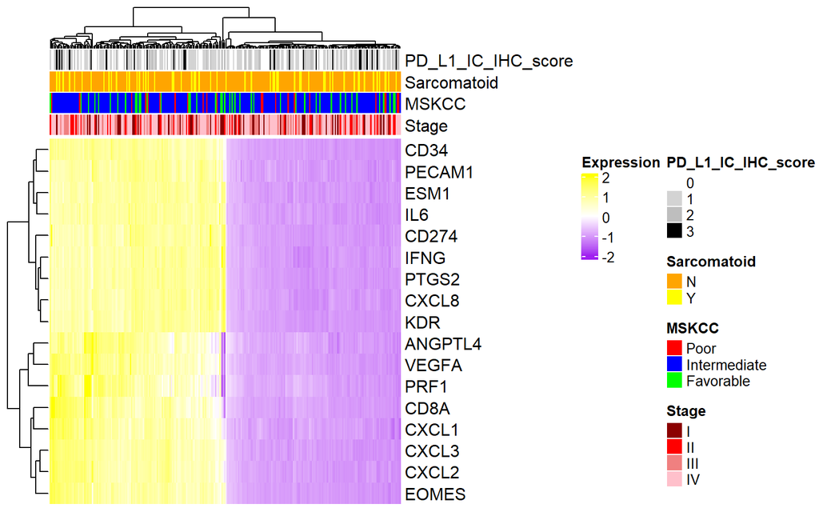

```r
# Define the genes for each category
angio_genes <- c("VEGFA", "KDR", "ESM1", "PECAM1", "ANGPTL4", "CD34")
teff_genes <- c("CD8A", "EOMES", "PRF1", "IFNG", "CD274")
myeloid_genes <- c("IL6", "CXCL1", "CXCL2", "CXCL3", "CXCL8", "PTGS2")

# Combine all genes into a single list
all_genes <- c(angio_genes, teff_genes, myeloid_genes)

# Prepare expression data
expression_data <- as.data.frame(t(expr_counts[rownames(expr_counts) %in% all_genes, ]))
expression_data$patientid <- rownames(expression_data)
rownames(expression_data) <- NULL
#colnames(expression_data) <- rownames(v$E)

# Check for matching patient IDs
intersecting_ids <- intersect(clin$patientid, colnames(expr_counts))
clin_data <- clin[clin$patientid %in% intersecting_ids, ]
clin_data$patientid <- as.character(clin_data$patientid)

expression_data <- expression_data[, c("patientid", setdiff(colnames(expression_data), "patientid"))]

# Merge clinical data with expression data
data_merged <- merge(clin_data, expression_data, by = "patientid", all.x = TRUE)

# Prepare top annotations
top_annotation <- data.frame(
  PatientID = data_merged$patientid,
  PD_L1_IC_IHC_score = factor(data_merged$ICSCORE, levels = c("0", "1", "2", "3")),
  Sarcomatoid = factor(ifelse(data_merged$SarcomatoidFeatures == "Y", "Y", "N"), levels = c("N", "Y")),
  MSKCC = factor(data_merged$MSKCC, levels = c("Poor", "Intermediate", "Favorable")),
  Stage = factor(data_merged$stage, levels = c("I", "II", "III", "IV"))
)

top_annotation <- na.omit(top_annotation)
patient_ids_in_top <- unique(top_annotation$PatientID)

filtered_expression_data <- expression_data[expression_data$patientid %in% patient_ids_in_top, ]

top_annotation$PatientID <- NULL

ha_top <- HeatmapAnnotation(df = top_annotation, col = list(
  PD_L1_IC_IHC_score = c("0" = "white", "1" = "lightgray", "2" = "gray", "3" = "black"),
  Sarcomatoid = c("N" = "orange", "Y" = "yellow"),
  MSKCC = c("Poor" = "red", "Intermediate" = "blue", "Favorable" = "green"),
  Stage = c("I" = "darkred", "II" = "red", "III" = "lightcoral", "IV" = "pink")
))

# Subset the filtered expression data to include only the genes of interest
filtered_expression_data <- filtered_expression_data[, c("patientid", all_genes)]
filtered_expression_data <- filtered_expression_data[-1]
filtered_expression_data  <- as.data.frame((filtered_expression_data))

normalized_expr <- as.data.frame(scale(filtered_expression_data))

expression_colors <- colorRamp2(c(-2, 0, 2), c("purple", "white", "yellow"))

# Plot the Heatmap with annotations
Heatmap(t(normalized_expr ), name = "Expression", col = expression_colors,
        top_annotation = ha_top, show_row_names = TRUE, show_column_names = FALSE,
        cluster_rows = TRUE, cluster_columns = TRUE)
```

### Heatmap with Gene Expression using `log2(TPM+0.001)` Normalization

This heatmap displays gene expression data across various samples using a `log2(TPM+0.001)` normalization:

In conclusion, both heatmaps give full insights into gene expression and clinical correlations, but they differ in normalization, grouping, and particular annotations, resulting in minor changes in patterns and context.

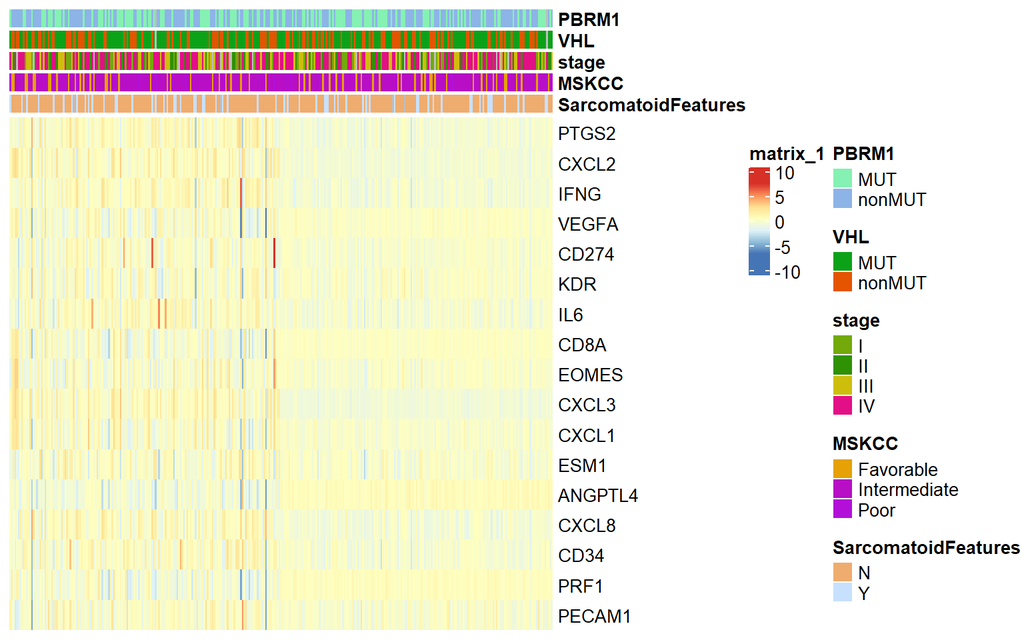

```r
# second heatmap based on our processed data "expr", which represents gene expression data normalized to log2(TPM+0.001)

# Define gene signatures
angiogenesis_genes <- c("VEGFA", "KDR", "ESM1", "PECAM1", "ANGPTL4", "CD34")
teff_genes <- c("CD8A", "EOMES", "PRF1", "IFNG", "CD274")
myeloid_inflammation_genes <- c("IL6", "CXCL1", "CXCL2", "CXCL3", "CXCL8", "PTGS2")

# Calculate z-scores for the expression data
expr_z_scores <- t(scale(t(expr[, sapply(expr, is.numeric)])))

# Reset row names of clinical data
rownames(clin) <- NULL

# Prepare patient annotations
patient_annotation <- clin %>%
  dplyr::select(patientid, SarcomatoidFeatures, MSKCC, stage, VHL, PBRM1) %>%
  mutate(across(everything(), as.character)) %>%
  column_to_rownames(var = "patientid")

patient_annotation <- patient_annotation[colnames(expr_z_scores), ]

# Generate the heatmap with annotations
pheatmap(expr_z_scores,
         cluster_rows = FALSE,
         cluster_cols = FALSE,
         show_rownames = TRUE,
         show_colnames = FALSE,
         annotation_col = patient_annotation)
```